# Project_lab2_Yuzhou

Yuzhou Wang

2025-04-16

```r
library(spatstat.geom)
library(sf)
load('BC_Covariates.Rda')
ls()
```

```
## [1] "DATA"
```

```r
head(summary(DATA))
```

```
##            Length Class           Mode
## Window      1     SpatialPolygons S4
## Elevation  10     im              list
## Forest     10     im              list
## HFI        10     im              list
## Dist_Water 10     im              list
```

```r
bees <- read.csv('dataset.csv')
coordinates(bees) <- ~decimalLongitude + decimalLatitude
proj4string(bees) <- CRS("+proj=longlat +datum=WGS84")
aea_crs <- CRS("+proj=aea +lat_0=45 +lon_0=-126 +lat_1=50 +lat_2=58.5 +x_0=1000000 +y_0=0 +datum=NAD83 +units=m +no_defs")
bees_proj <- spTransform(bees, aea_crs)
bee_coords <- coordinates(bees_proj)
head(bees,2)
```

```
##         coordinates    gbifID                           datasetKey occurrenceID
## 1 (-118.9161, 50.4) 735215733 275319e1-f91c-406f-b239-62cb9d4185cb   LEM0258825
## 2 (-118.9161, 50.4) 735215732 275319e1-f91c-406f-b239-62cb9d4185cb   LEM0258824
##    kingdom     phylum   class       order   family   genus              species
## 1 Animalia Arthropoda Insecta Hymenoptera Vespidae Vespula Vespula pensylvanica
## 2 Animalia Arthropoda Insecta Hymenoptera Vespidae Vespula Vespula pensylvanica
##   infraspecificEpithet taxonRank                           scientificName
## 1                   NA   SPECIES Vespula pensylvanica (de Saussure, 1857)
## 2                   NA   SPECIES Vespula pensylvanica (de Saussure, 1857)
##   verbatimScientificName verbatimScientificNameAuthorship countryCode
## 1                                        (Saussure, 1857)          CA
## 2                                        (Saussure, 1857)          CA
##         locality    stateProvince occurrenceStatus individualCount
## 1 Trinity Valley British Columbia          PRESENT               1
## 2 Trinity Valley British Columbia          PRESENT               1
##                       publishingOrgKey coordinateUncertaintyInMeters
## 1 182287da-fe0f-457f-ac06-2b8f4c7680fd                            NA
## 2 182287da-fe0f-457f-ac06-2b8f4c7680fd                            NA
##   coordinatePrecision elevation elevationAccuracy depth depthAccuracy eventDate
## 1                  NA        NA                NA    NA            NA 1939/4/28
## 2                  NA        NA                NA    NA            NA  1939/5/2
##   day month year taxonKey speciesKey      basisOfRecord   institutionCode
## 1  28     4 1939  1311698    1311698 PRESERVED_SPECIMEN McGill University
## 2   2     5 1939  1311698    1311698 PRESERVED_SPECIMEN McGill University
##   collectionCode catalogNumber recordNumber identifiedBy dateIdentified license
## 1           LEMQ    LEM0258825           NA                             CC0_1_0
## 2           LEMQ    LEM0258824           NA                             CC0_1_0
##        rightsHolder  recordedBy typeStatus establishmentMeans
## 1 McGill University C.V. Morgan         NA                 NA
## 2 McGill University C.V. Morgan         NA                 NA
##            lastInterpreted mediaType
## 1 2025-02-01T03:52:23.555Z
## 2 2025-02-01T03:52:23.565Z
##                                                                                                  issue
## 1 GEODETIC_DATUM_ASSUMED_WGS84;OCCURRENCE_STATUS_INFERRED_FROM_INDIVIDUAL_COUNT;INSTITUTION_MATCH_NONE
## 2 GEODETIC_DATUM_ASSUMED_WGS84;OCCURRENCE_STATUS_INFERRED_FROM_INDIVIDUAL_COUNT;INSTITUTION_MATCH_NONE
```

```r
window_sf <- st_as_sf(DATA$Window)
win <- as.owin(window_sf)

bee_ppp <- ppp(x = bee_coords[,1], y = bee_coords[,2], window = win)
table(inside.owin(bee_ppp$x, bee_ppp$y, win))
```

```
##
## TRUE
## 1112
```

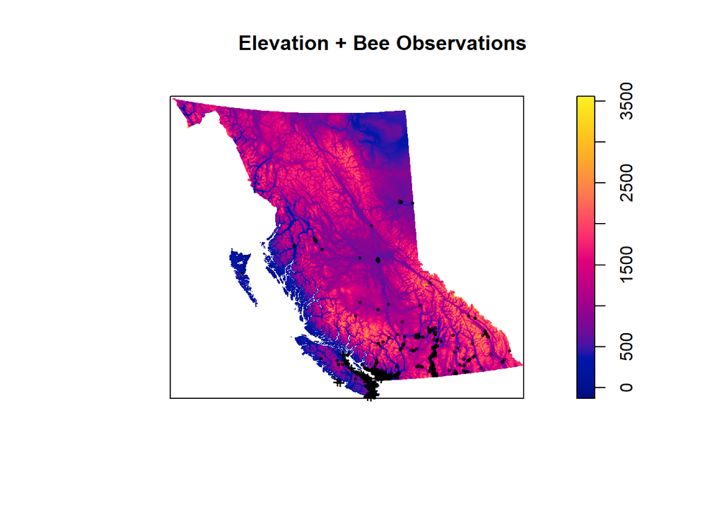

```r
plot(DATA$Elevation, main = "Elevation + Bee Observations")
plot(bee_ppp, add = TRUE, pch = 20, cex = 0.6)
```

```r
library(spatstat.geom)

bee_win_km <- rescale(Window(bee_ppp), s = 1000, unitname = "km")

npoints(bee_ppp) / area(bee_win_km)
```

```
## [1] 0.001172671
```

In this section, we estimated the first-order intensity of bee observations across the study region. Initially, the intensity was calculated in units of points per square meter, resulting in an extremely small value (~1.17e-09), which is difficult to interpret. To make the results more intuitive, we rescaled the spatial window to units of square kilometers, yielding a new intensity estimate of ~0.00117 bees/km².